# Sick dataset analysis

Aleksandra Wichrowska

Out task was analysing and training an explainable model on dataset ‘sick’. It’s a dataset taken from OpenML website. It contains data about patients with and without thyroid disease.

## 1.Preprocessing

#### 1.1 Delete some columns

First step in preprocessing will be deleting unnecessary columns:

- TBG - only NA values
- TBG-measured - only one value
- hypopituitary - only one value in train

```r
dataset <- dataset_raw %>%
  select(-c(TBG, TBG_measured,hypopituitary))
```

#### 1.2 One hot encoding

Next I will do one-hot-encoding of factors variables: referral_source and sex.

```r
dummy <- dummyVars(~referral_source , data = dataset)
new_vars <- predict(dummy, dataset)
dataset <- dataset %>% select(-referral_source)
dataset <- cbind(dataset, new_vars)

dataset <- dataset %>% select(-referral_source.other)

dataset$sex <- as.numeric(dataset$sex == 'F') # sex variable to 0/1

dataset$Class = as.factor(as.numeric(dataset$Class=='sick'))
```

#### 1.3 Correlation matrix

Next look into correlation matrix.

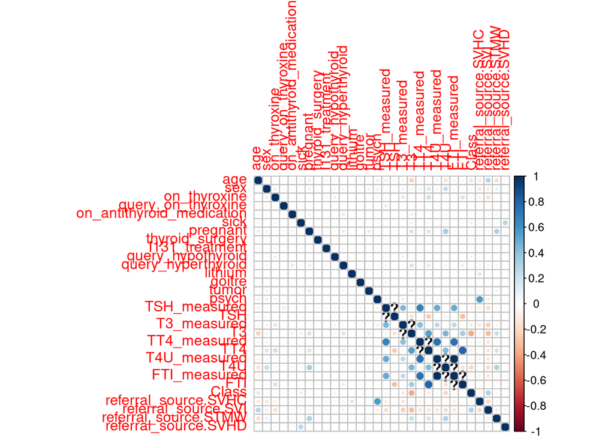

```r
corrplot(correlation_matrix)
```

We can find two correlated variables: FTI_measured and T4U_measured. Correlation:

```r
cor(as.numeric(dataset$FTI_measured), as.numeric(dataset$T4U_measured))
```

```
## [1] 0.9971181
```

```r
dataset <- dataset %>% select(-T4U_measured)
```

So I decided to delete one of them.

#### 1.4 Split dataset

Now we can split our dataset to train and test subsets (with `indeksy-trenignowe.txt` file)

After preprocessing we can start training first model. I will try model from `rpart` package - decision tree.

## 2. Training

I will use `mlr` library to train models, so let’s make `auprc` measure to this package.

#### 2.1 Base rpart model

Let’s begin with training some base model - rpart with default parameters.

```
##   auc.test.mean auprc.test.mean
##       0.9512168       0.8512804
```

#### 2.2 Rpart after imputation

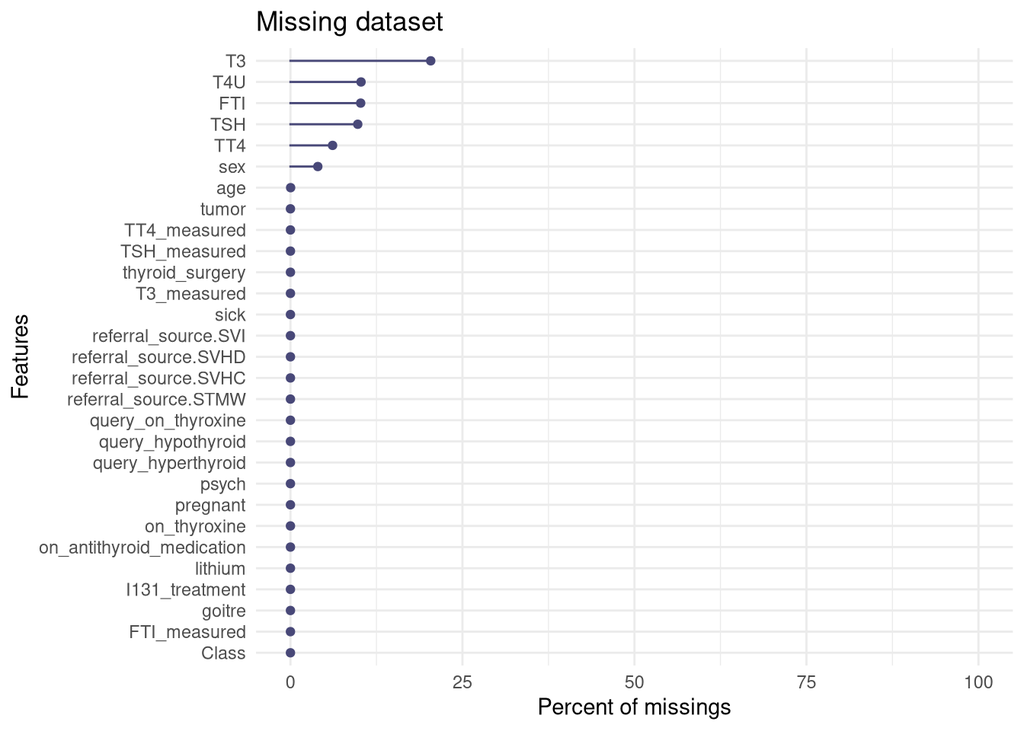

For `sex` variable I impute value `F` with probability equal to female ratio.

In addition for `age` variable I detected some outliers (greater than `120`) and impute them with mean also.

```
##   auc.test.mean auprc.test.mean
##       0.9540734       0.8605861
```

After imputation we have a better model performance. I tried also some other method of imputation like knnImputation but it doesn’t work.

#### 2.3 Rpart after hyperparameters tuning

I tried also tuning of hyperparameters.

```
##   auc.test.mean auprc.test.mean
##       0.9428945       0.8721022
```

## 3. Final model

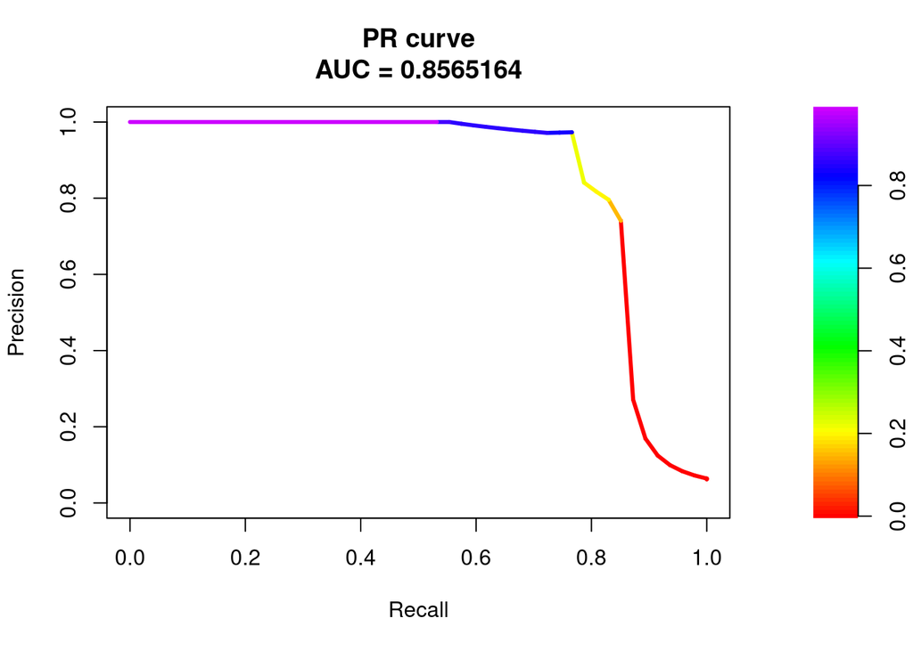

```
## [1] 0.8565164
```